# R e Rstudio

Carlos Cinelli

14 de janeiro de 2015

# R e Rstudio

## Instalação

Instalar o R e o RStudio é bastante fácil, pois ambos já vêm com distribuições compiladas para Windows, Mac e Linux. Se você ainda não os tem instalados em seu computador, este será seu primeiro exercício.

O R é gratuito e está disponível no site do CRAN (The Comprehensive R Archive Network). O RStudio também tem uma versão *desktop* gratuita disponível no site do [RStudio](http://www.rstudio.com/products/rstudio/#Desk). Em ambos os casos, baixe a versão compatível com seu sistema operacional e siga as instruções de instalação.

Com esses dois softwares podemos continuar boa parte do nosso livro. Entretanto, para ter um ambiente completo de desenvolvimento no R, você também precisará instalar:

- Uma distribuição de Latex, como o [MikTex](http://miktex.org) para Windows ou [MacTex](https://tug.org/mactex/) para Mac;
- E se você estiver usando o windows, a versão mais recente do [RTools](http://cran.r-project.org/bin/windows/Rtools/) (para criarmos pacotes e integrar o R com C++).

## R Gui

Ao instalar o R, automaticamente também é instalada uma interface gráfica chamada R Gui. Abra o R no seu computador. A primeira tela que você verá é a do console. Abra também uma tela de editor de texto em “file” -> “new script”.

[figure not shown]

Escreva os seguintes comandos no editor de texto e aperte “ctrl+R”.

```r
1+1
```

O comando será enviado para o console. Agora faça o seguinte gráfico:

```r
plot(1:10)
```

Uma nova tela será aberta com o gráfico. Saia do R Gui escrevendo q() no console ou apertando “alt+f4”. Ele irá perguntar se você deseja salvar o trabalho e o script. Clique em “não” para os dois casos. Estamos saindo do R Gui pois iremos trabalhar no RStudio.

## RStudio

Apesar de o R vir com uma interface gráfica bem interessante, existe um IDE (Integrated Development Environment - ou, em português, Ambiente de Desenvolvimento Integrado) chamado RStudio, com várias funcionalidades e gratuito. Neste livro utilizaremos o R sempre em conjunto com o RStudio.

O RStudio tem algumas vantagens em relação ao R Gui:

- Highlight do código;
- Autocomplete;
- Match automático de parenteses e chaves;
- Interface intuitiva para objetos, gráficos, script;
- Projetos;
- Interação com HTML, entre outras.

## RStudio

Abra o RStudio em seu computador e inicie um novo Script em “File” -> “New File” -> “New RScript”. Você também pode fazer isso com **“CTRL + SHIFT + N”** ou acessando o botão abaixo.

[figure not shown]

## RStudio

[figure not shown]

## Comandos pelo Script

Acostume-se a escrever o código no Script ao invés de ficar escrevendo diretamente no console.

Escreva o código abaixo no Script:

```r
1+1
```

E aperte “ctrl” + “enter”. Isso envia o comando para o console e o resultado é exibido logo abaixo.

```r
1+1
```

```
## [1] 2
```

## Comandos pelo Script

Agora escreva o seguinte código no Script.

```r
# Gráfico dos números de 1 a 10
plot(1:10)
```

O primeiro comando *“# Gráfico dos números de 1 a 10”* é, na verdade, um comentário. Comentários em Scripts do R são seguidos do símbolo #, e tudo que estiver após # não será executado. É uma boa prática comentar seu código, para que ele seja de fácil manutenção, tanto para você mesmo quanto para outros colegas. O segundo comando é de um gráfico. Aperte “ctrl” + “enter” nas duas linhas. O gráfico aparecerá no canto inferior direito do RStudio.

## Comandos pelo Script

[figure not shown]

## Comandos pelo Script

Agora digite o seguinte comando no editor e aperte “ctrl” + “enter”:

```r
x <- 15
```

Atribuímos o valor 15 à variável x. Note que isso aparece no canto superior direito do RStudio.

[figure not shown]

## Comandos pelo Script

O RStudio tem autocomplete. Escreve apenas `plo` e aperte **Tab**.

[figure not shown]

## Comandos pelo Script

Isso também funciona dentro da função, para vermos os parâmetros disponíveis. Escreva `plot()` e aperte **Tab**.

[figure not shown]

## Comandos pelo Script

Outras teclas de atalho:

- **CTRL + 1**: Passa o cursor para o Script;
- **CTRL + 2**: Passa o cursor para o console;
- **SETA PARA CIMA (no console)**: acessa o histórico de comandos anteriores.

Abra um novo Script:

- **CTRL + ALT + SETA PARA ESQUERDA OU DIREITA**: Navega entre as abas de script abertas.

## Comandos pelo Script

Outras teclas de atalho:

- **CTRL + SHIFT + P**: “Previous command”, roda o último comando executado;
- **CTRL + SHIFT + ENTER**: “Source”. Executa o Script inteiro;
- **CTRL + S**: Salva o Script;

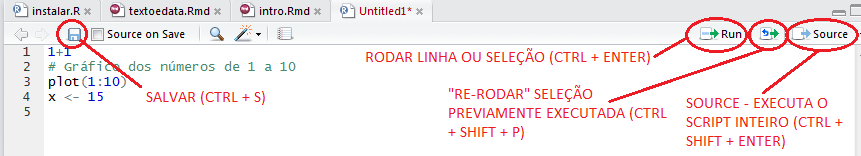

## Comandos pelo Script

- **CTRL + L**: Limpa o console;
- **CTRL + F**: Busca (e substituição). Aceita REGEX;
- **CTRL + SHIFT + K**: Compila “Notebook” em PDF, HTML ou Word;
- **ALT + SHIFT + K**: Veja os outros atalhos.

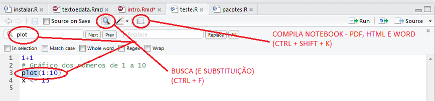

## Ajuda - Função Específica

```r
?mean; help(mean)
```

[figure not shown]

## Ajuda - Função Específica

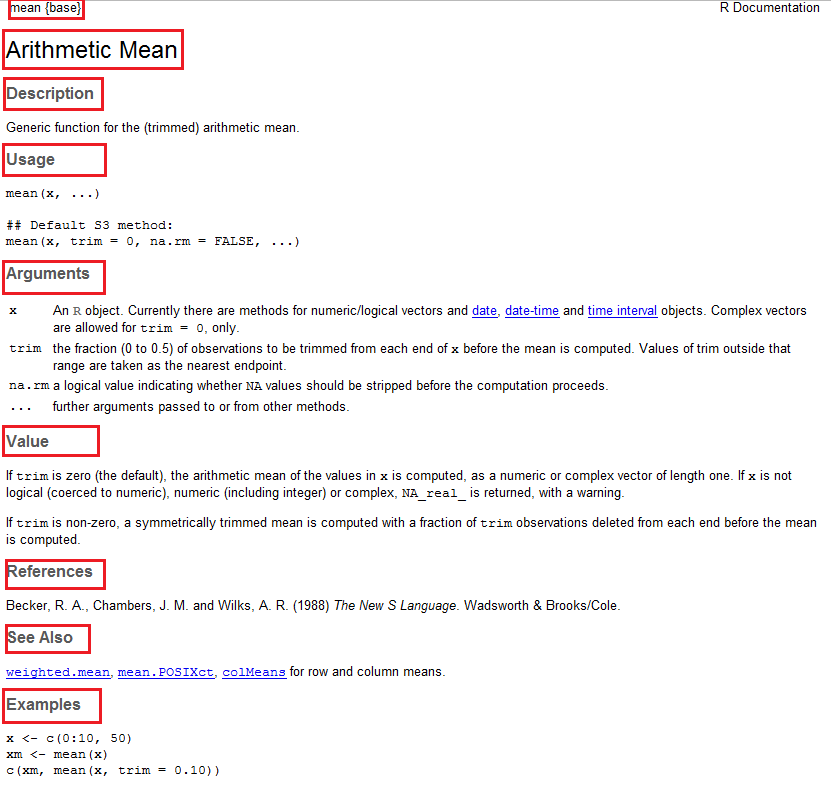

## Ajuda - Busca por String

```r
??"normal distribution"; help.search("normal distribution")
```

[figure not shown]

## Ajuda - Internet

- StackOverflow (em Inglês e Português)

[figure not shown]

## Ajuda - Internet

- **Grupos de e-mail**: www.r-project.org/mail.html
  - **R Help**: lista de e-mails principal, para dúvidas gerais.
  - **R Announce**: Lista de anúncios sobre desenvolvimento do R.
  - **R Packages**: Lista de anúncios sobre pacotes do R.
  - **R Devel**: Lista de discussão de desenvolvedores no R.
- **Blogs**
  - **R Bloggers**: consolidador de blogs sobre R.

## Pacotes

Configurar o R para encontrar os pacotes já instalados nos computadores do curso.

```r
# Onde o R está buscando os pacotes?
.libPaths()

# Vamos dizer ao R para buscar
# Também em "D:/Curso de R/Pacotes"
.libPaths(c("D:/Curso de R/Pacotes", .libPaths()))
```

## Pacotes

A principal forma de distribuição de códigos no R é por meio de pacotes. Um pacote pode ser entendido como um conjunto de códigos auto-contido que adiciona funcionalidades ao R.

Ao carregar um pacote, você está adicionando suas funções ao `search` da seção, permitindo que você chame estas funções diretamente. Por exemplo, a função `mvrnorm`, que gera números aleatórios de uma normal multivariada, está no pacote `MASS`.

```r
Sigma <- matrix(c(10,3,3,2),nrow=2,ncol=2) # Matriz de Var-Covar
mu <- c(1, 10) # Médias
x <- mvrnorm(n=100, mu, Sigma) # Tenta gerar 100 obs, mas dá erro
```

```
## Error in eval(expr, envir, enclos): não foi possível encontrar a função "mvrnorm"
```

```r
library(MASS) # Carrega pacote
x <- mvrnorm(n=100, mu, Sigma) # Agora funciona
```

## Pacotes

Para ver o que está no `search` do R, utilize a função `search()`. Note que o pacote MASS agora esta lá.

```r
search()
```

```
##  [1] ".GlobalEnv"        "package:MASS"      "package:stats"
##  [4] "package:graphics"  "package:grDevices" "package:utils"
##  [7] "package:datasets"  "package:methods"   "Autoloads"
## [10] "package:base"
```

Para descarregar um pacote, utilize a função `detach()`.

```r
detach(package:MASS)
```

Às vezes pacotes tem o mesmo nome de funções. Neste caso, se ambos forem carregados, a função que prevalece é a do pacote que foi carregado por último. Uma outra forma de resolver isso é usar o nome do pacote e o operador `::` antes de chamar a função. Neste caso não há ambiguidade.

```r
x <- MASS::mvrnorm(n=100, mu, Sigma)
```

## Pacotes

Você também pode carregar ou descarregar pacotes pelo menu do canto inferior direito do RStudio, clicando na caixa ao lado do nome do pacote.

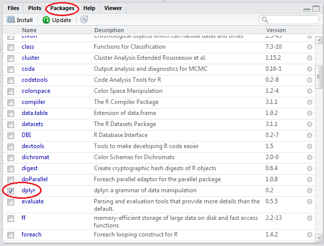

## Pacotes

```r
############## Não rode ##################
utils::install.packages("dplyr",
                        repos="http://cran.r-project.org/")

remove.packages(dplyr)
############## Não rode ##################
```

A opção `repos="http://cran.r-project.org/"` diz ao R que é para baixar o pacote deste repositório. O `utils::` antes de `install.packages` diz que queremos acessar a função `install.packages` contida no pacote `utils`.

## Pacotes, CRAN e Sites

Grande parte dos pacotes do R estão centralizados em um repositório chamado CRAN (The Comprehensive R Archive Network), com diversos espelhos ao redor do mundo.

Agora, vamos explorar um pouco o site oficial do R, **www.r-project.org**, e do CRAN, **cran.r-project.org**.

- Manuais, livros, documentação;
- Listas de e-mais;
- The R Journal;
- Lista de pacotes;
- Task Views.

# Um breve exemplo

## Imóveis do Plano Piloto

Para ilustrar uma análise no R, veremos um exemplo simples com ofertas online de apartamentos à venda no Plano Piloto,do site *Wimoveis*. Os dados foram obtidos por meio de webscraping utilizando o R e já passaram por um processo de “limpeza” prévio.

Não se preocupe em entender os comandos agora, iremos trabalhar isso no decorrer do curso.

## Imóveis do Plano Piloto

```r
# Carregando os pacotes que vamos usar
library(dplyr)
library(ggplot2)
library(xtable)


# Carregando os dados
dados <- readRDS("Dados/wi.venda.rds")

# Vendo a estrutura dos dados
str(dados, vec.len=1)
```

```
## 'data.frame':    3786 obs. of  9 variables:
##  $ bairro   : chr  "Noroeste " ...
##  $ location : chr  "SQNW 310 " ...
##  $ preco    : num  150000 175000 ...
##  $ quartos  : num  3 1 ...
##  $ m2       : num  117 30 ...
##  $ corretora: chr  "12220" ...
##  $ data     : Date, format: "2014-01-23" ...
##  $ link     : chr  "/imovel/venda-apartamento-brasilia-df-3-quartos-sqnw-310-339700" ...
##  $ pm2      : num  1282 ...
```

## Imóveis do Plano Piloto

```r
# Calculando medianas por bairro
mediana_bairro <- dados %>%
  group_by(bairro) %>% summarise(Median_Preco = median(preco),
                                 Median_Quarto = median(quartos),
                                 Median_pm2 = median(pm2),
                                 N=n())
mediana_bairro
```

```
## Source: local data frame [4 x 5]
##
##       bairro Median_Preco Median_Quarto Median_pm2    N
## 1 Asa Norte        830000             3   8928.571 1331
## 2   Asa Sul       1030000             3   8800.491 1036
## 3  Noroeste       1070000             3   9934.211  635
## 4  Sudoeste        899500             3   9705.882  784
```

## Imóveis do Plano Piloto

```r
# Rodando um modelo linear
modelo <- lm(preco~m2*bairro + quartos , data=dados)
summary(modelo)
```

```
##
## Call:
## lm(formula = preco ~ m2 * bairro + quartos, data = dados)
##
## Residuals:
##      Min       1Q   Median       3Q      Max
## -3889078  -105771   -10453    90518  2263876
##
## Coefficients:
##                     Estimate Std. Error t value Pr(>|t|)
## (Intercept)         -97799.4    17814.5  -5.490 4.29e-08 ***
## m2                   10559.4      157.3  67.147  < 2e-16 ***
## bairroAsa Sul      -112419.9    22855.8  -4.919 9.08e-07 ***
## bairroNoroeste      247778.5    24868.8   9.963  < 2e-16 ***
## bairroSudoeste      -89675.9    24383.6  -3.678 0.000239 ***
## quartos             -17004.4     6803.3  -2.499 0.012481 *
## m2:bairroAsa Sul       923.5      181.6   5.085 3.85e-07 ***
## m2:bairroNoroeste    -1541.1      191.2  -8.061 1.01e-15 ***
## m2:bairroSudoeste     1700.5      212.1   8.018 1.42e-15 ***
## ---
## Signif. codes:  0 '***' 0.001 '**' 0.01 '*' 0.05 '.' 0.1 ' ' 1
##
## Residual standard error: 249200 on 3777 degrees of freedom
## Multiple R-squared:  0.8702, Adjusted R-squared:  0.8699
## F-statistic:  3164 on 8 and 3777 DF,  p-value: < 2.2e-16
```

## Imóveis do Plano Piloto

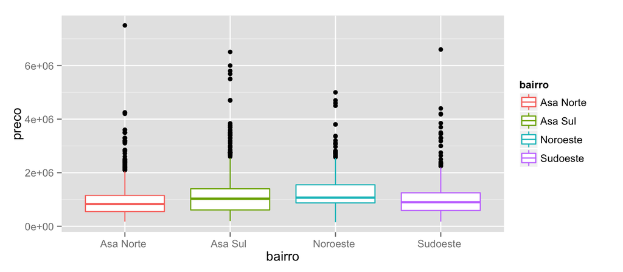

```r
# Box-Plot dos precos por bairro
ggplot(dados, aes(bairro, preco, color=bairro)) + geom_boxplot()
```

## Imóveis do Plano Piloto

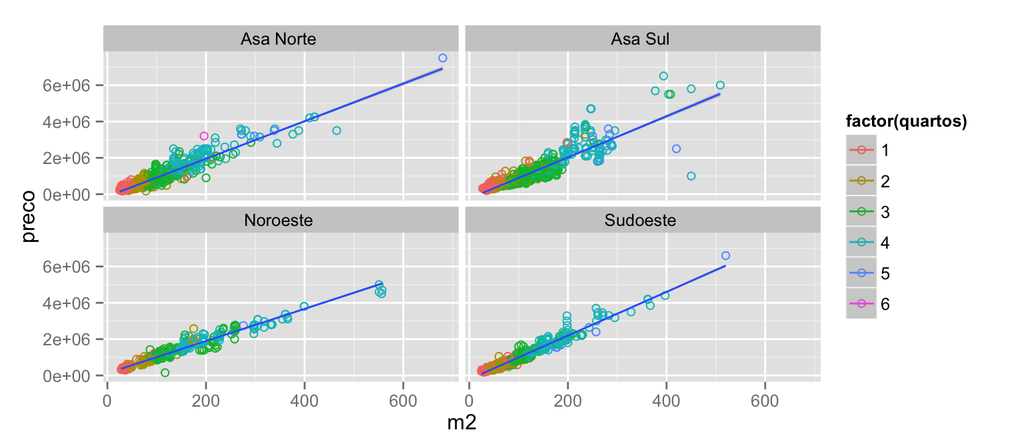

```r
# Gráfico de dispersão com regressão
ggplot(dados, aes(m2, preco, color=factor(quartos), group=1)) +
  geom_point(shape=1) + geom_smooth(method="lm") +
  facet_wrap(~bairro)
```